# lab4

Abeoseh Flemister

2026-02-26

```r
annotation <- read.table("./longitdunalRNASeqData/nc101_Annotations.txt", sep = "\t", header = TRUE, row.names = 1)
datacounts <- read.table("./longitdunalRNASeqData/nc101_scaff_dataCounts.txt", sep = "\t", header = TRUE, row.names = 1)
```

## (2) On a log10-log10 scale, show a plot of the counts for the two samples “D2_01” and “D2_02”.

Qualitatively, do the biological replicates appear to have similar patterns of gene expression?

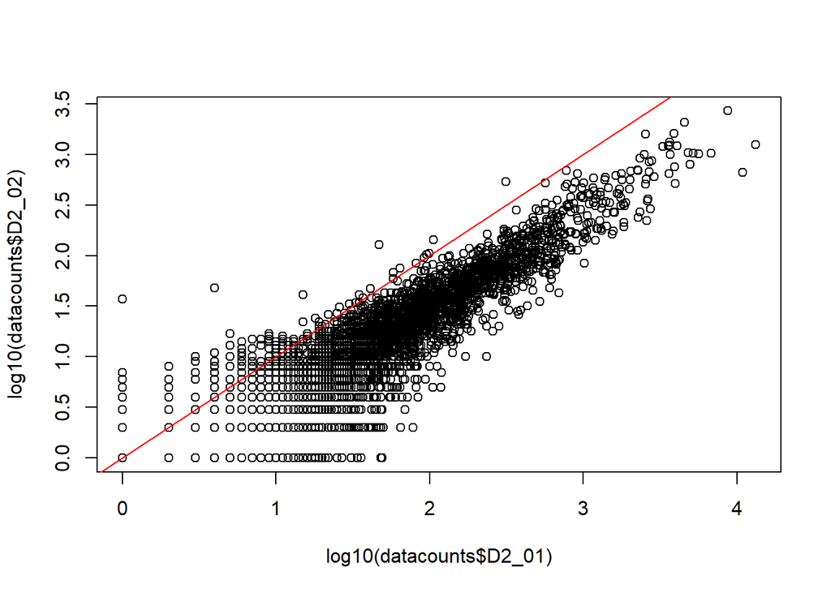

## (3) On a log10-log10 scale, plot the variance of all genes (across all genes) vs. the mean (across all genes) with a red line on your graph representing the identity line. Does the mean equal the variance for these samples?

(The commands apply(myT, 1, mean) and apply(myT, 1, var) will be of some use).

**The mean is not exactly equal to the variance for all datapoints which we can see deviations from the identity line. The variance is greater than the mean.**

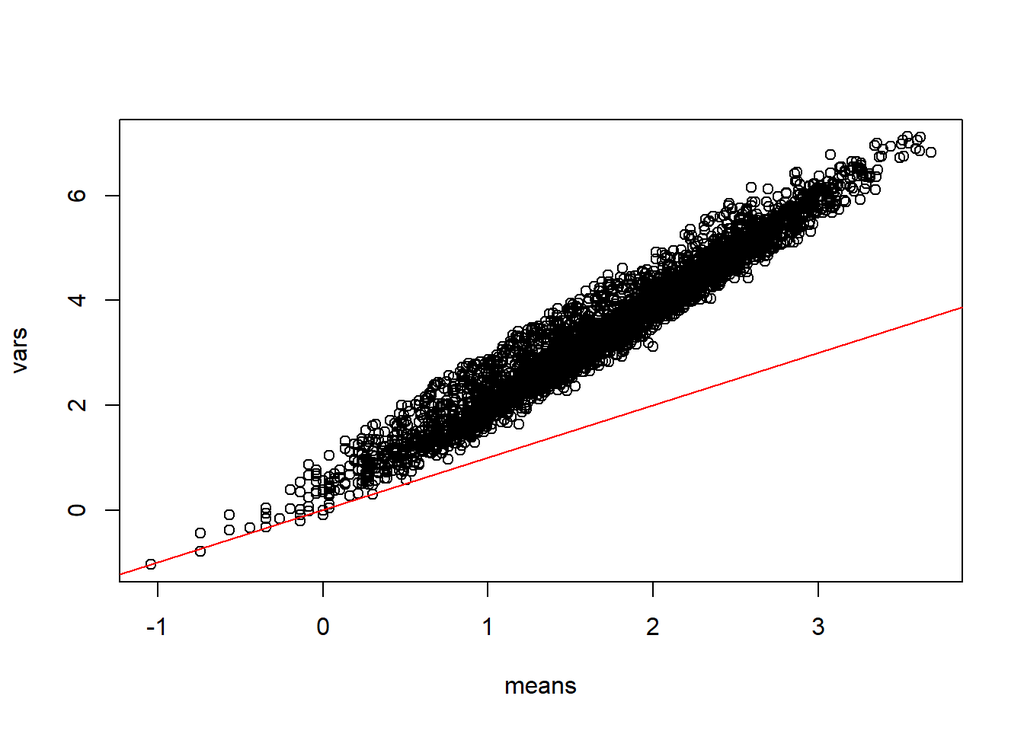

```r
## If there are all 0s in a row, log10 will be undefined
datacounts_filtered = datacounts[apply(datacounts, 1, sum) != 0,]
means = log10(apply(datacounts_filtered, 1, mean))
vars = log10(apply(datacounts_filtered, 1, var))

plot(means, vars)

abline(0, 1, col = "red")
```

## (4) Consider the first gene in the spreadsheet (e.g. NC101_00003). Make a two by two contingency table:

|  | Sequences in D2_01 | Sequences in D2_02 |
| --- | --- | --- |
| Assigned to NC101_00003 |  |  |
| Not assigned to NC101_00003 |  |  |

```r
suppressPackageStartupMessages(library(dplyr))

is_NC101_00003 = datacounts %>% select(D2_01, D2_02) %>% filter(row.names(datacounts) == "NC101_00003")

not_NC101_00003 = datacounts %>% select(D2_01, D2_02) %>% filter(row.names(datacounts) != "NC101_00003") %>% apply(2, sum)

fisher.test(rbind(is_NC101_00003, not_NC101_00003))
```

```
##
##  Fisher's Exact Test for Count Data
##
## data:  rbind(is_NC101_00003, not_NC101_00003)
## p-value = 1.67e-11
## alternative hypothesis: true odds ratio is not equal to 1
## 95 percent confidence interval:
##  2.115313 4.696220
## sample estimates:
## odds ratio
##   3.095943
```

## (5) Now generate a p-value for all the genes in the spreadsheet from the Fisher test. Plot out those p-values in a histogram.

- Are they uniformly distributed? **The p-values are not uniformly distributed.**
- Would you expect them to be? **If I were to accept the null hypothesis I would expect the p-values to be uniformly distributed**
- Are the p-values more significant, less significant or what we would expect under a uniform distribution? **Since the p-values are not uniformally distributed they are different than what would expect if we were to accept the null hypothesis.**

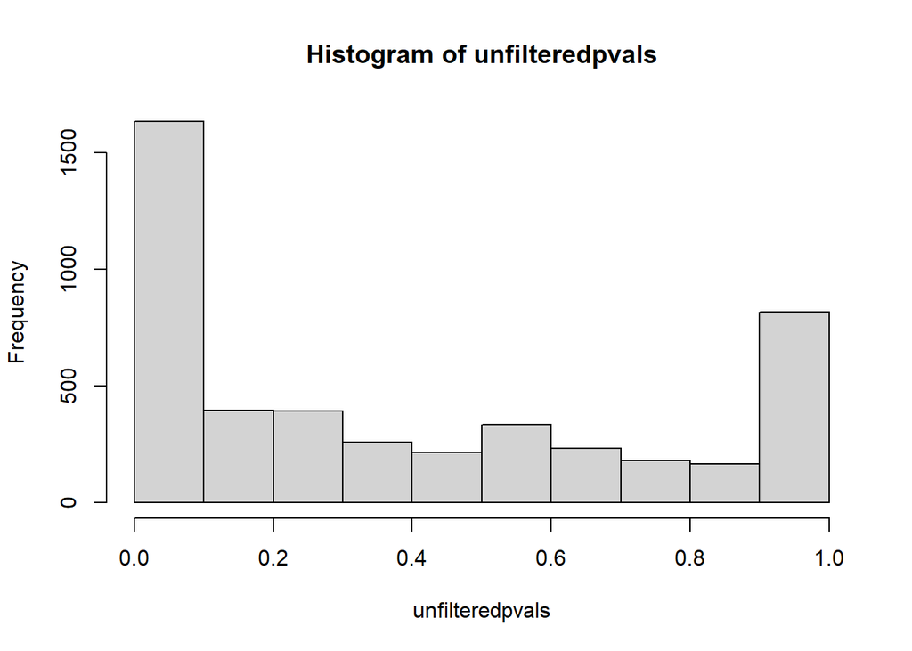

```r
genes = row.names(datacounts)
unfilteredpvals = vector(length = length(genes))
i = 1

for( gene in genes){

  is_gene = datacounts %>% select(D2_01, D2_02) %>% filter(row.names(datacounts) == gene)

  not_gene = datacounts %>% select(D2_01, D2_02) %>% filter(row.names(datacounts) != gene) %>% apply(2, sum)

  unfilteredpvals[i] = fisher.test(rbind(is_gene, not_gene))$p.value


  i = i + 1
}
hist(unfilteredpvals, plot = TRUE, breaks = 10)
```

- How does the p-value distribution change if you remove low abundance genes (with for example myT <- myT[ (myT$D2_01 + myT$D2_02 > 50),]
  - Are they uniformly distributed? **The p-values are still not normally distributed**
  - Would you expect them to be? **If I were to accept the null hypothesis I would expect the p-values to be uniformly distributed**
  - Are the p-values more significant, less significant or what we would expect under a uniform distribution? **Since the p-values are still not uniformly distributed they are different than what would expect if we were to accept the null hypothesis. The high p-values were from the low abundance genes.**

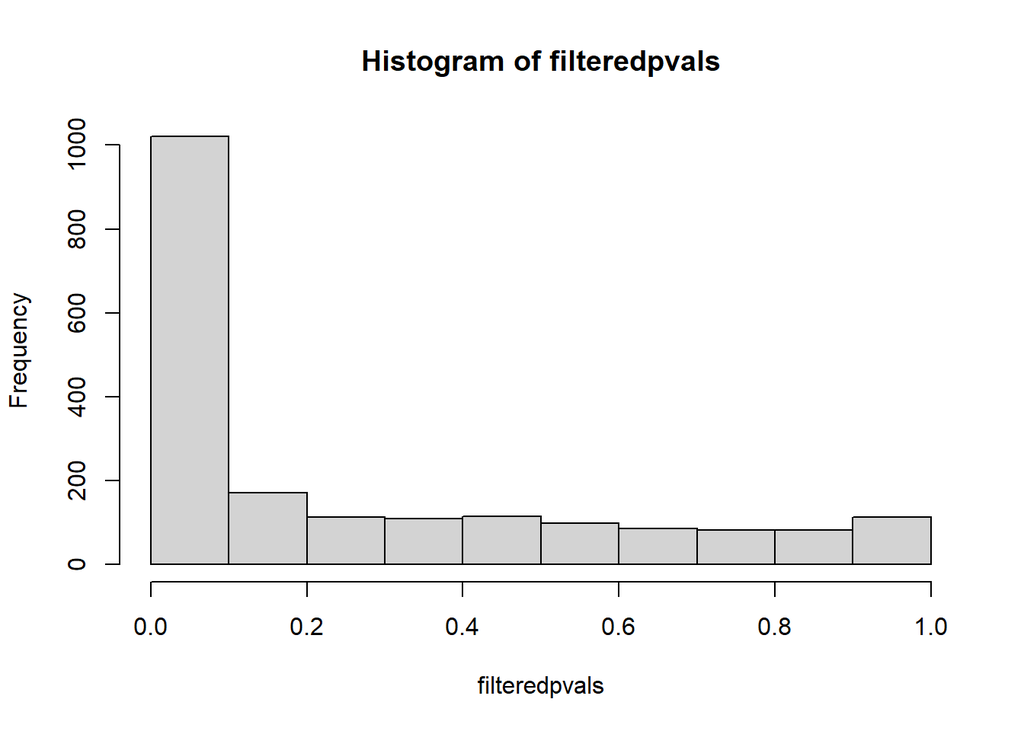

```r
datacounts_filtered = datacounts[ (datacounts$D2_01 + datacounts$D2_02 > 50),]
genes = row.names(datacounts_filtered)
filteredpvals = vector(length = length(genes))
i = 1

for( gene in genes){

  is_gene = datacounts_filtered %>% select(D2_01, D2_02) %>% filter(row.names(datacounts_filtered) == gene)

  not_gene = datacounts_filtered %>% select(D2_01, D2_02) %>% filter(row.names(datacounts_filtered) != gene) %>% apply(2, sum)

  filteredpvals[i] = fisher.test(rbind(is_gene, not_gene))$p.value

  i = i + 1
}


hist(filteredpvals, plot = TRUE, breaks = 10)
```

## (6) Add 1 to every value in the table ( with something like myT = myT + 1 ).

- This is called adding a pseudo-count.
- Now consider the first gene (NC101_00003 ) again.
- From the first experiment, calculate expected frequency = p = (# Assigned to NC101_00003 in D2_01)/total # of sequences in D2_01)
- Now use poisson.test to assign a p-value for the null hypothesis that value of p derived from D2_01 could have produced the number of reads observed for this gene in D2_02 .

```r
pseudocount_datacounts <- datacounts %>% select(D2_01, D2_02) + 1

is_NC101_00003 = pseudocount_datacounts %>% select(D2_01) %>% filter(row.names(datacounts) == "NC101_00003") %>% sum()

total_seqs_d1 = pseudocount_datacounts %>% select(D2_01) %>% sum()

expected_frequency = pseudocount_datacounts %>% select(D2_01) %>% filter(row.names(pseudocount_datacounts) == "NC101_00003") / total_seqs_d1

total_seqs_d2 = pseudocount_datacounts %>% select(D2_02) %>% sum()

observed_d2 <- pseudocount_datacounts["NC101_00003", "D2_02"]

# poisson.test(is_NC101_00003, total_seqs_d2, expected_frequency$D2_01)
poisson.test(observed_d2, T = total_seqs_d2, r = expected_frequency$D2_01)
```

```
##
##  Exact Poisson test
##
## data:  observed_d2 time base: total_seqs_d2
## number of events = 30, time base = 162959, p-value = 1.139e-13
## alternative hypothesis: true event rate is not equal to 0.0005640621
## 95 percent confidence interval:
##  0.0001242084 0.0002628076
## sample estimates:
##   event rate
## 0.0001840954
```

## (7) Repeat the calculation in (6) for every gene in the spreadsheet. Graph these p-values against the p-values produced in (5) on a log10-log10 plot. How well do they agree?

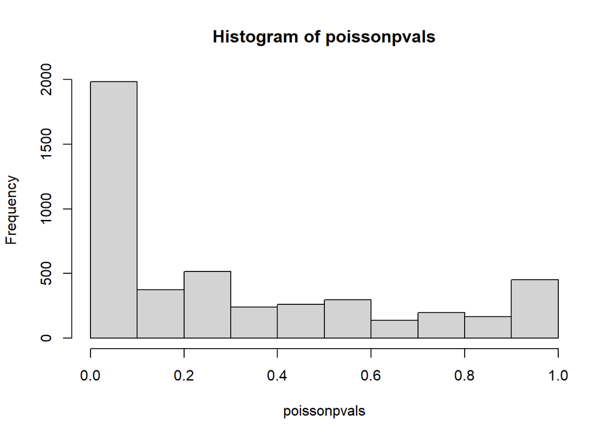

```r
pseudocount_datacounts <- datacounts %>% select(D2_01, D2_02) + 1

genes = row.names(pseudocount_datacounts)
poissonpvals = vector(length = length(genes))
i = 1

for (gene in genes){

  is_gene = pseudocount_datacounts %>% select(D2_01) %>% filter(row.names(datacounts) == gene) %>% sum()

  total_seqs_d1 = pseudocount_datacounts %>% select(D2_01) %>% sum()

  expected_frequency = pseudocount_datacounts %>% select(D2_01) %>% filter(row.names(datacounts) == gene) / total_seqs_d1

  total_seqs_d2 = pseudocount_datacounts %>% select(D2_02) %>% sum()

  observed_d2 <- pseudocount_datacounts[gene, "D2_02"]

  poissonpvals[i] = poisson.test(observed_d2, total_seqs_d2, expected_frequency$D2_01)$p.value



  i = i + 1

}

hist(poissonpvals, plot = TRUE, breaks = 10)
```

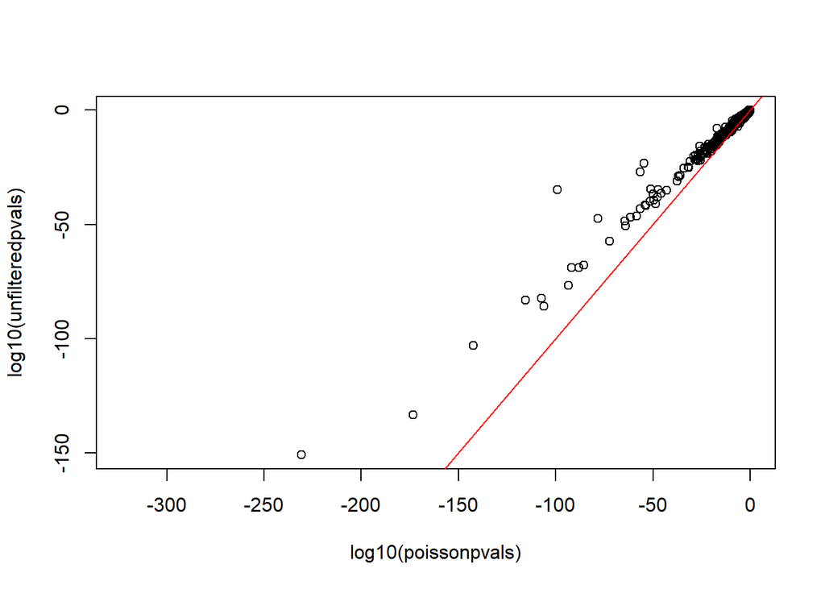

```r
plot(log10(poissonpvals), log10(unfilteredpvals))
abline(0,1, col = "red")
```

**There is some agreement between the two tests. However, the assumptions of the possion test were violated so the p-values cannot be trusted. The poisson assumes the mean equals the variance which is not true in our dataset.**